# Geog533 Lab 7 - Correlation

Wu_Yanan

## Question 1

This is Exercise 1 in Chapter 7 of the Textbook [R].

### Problem 1a

Find the correlation coefficient, *r*, for the following sample data on income and education:

```r
library(knitr)
obs <- seq(1:5)
income <- c(30,28,52,40,35)
edu <- c(12,13,18,16,17)
df <- data.frame(obs,income,edu)
names(df) <- c("Observation","Income ($*1000)","Education (Years)")
kable(df)
```

| Observation | Income ($*1000) | Education (Years) |
| --- | --- | --- |
| 1 | 30 | 12 |
| 2 | 28 | 13 |
| 3 | 52 | 18 |
| 4 | 40 | 16 |
| 5 | 35 | 17 |

Solution 1a

```r
income <- c(30,28,52,40,35)
edu <- c(12,13,18,16,17)
df <- data.frame(income,edu)
ct <- cor.test(income, edu, method = "pearson")
ct$estimate[[1]]
```

```
[1] 0.83577
```

```r
if (ct$p.value > 0.05){
  print("The null hypothesize is true")
}else{
  print("The null hypothesize is not true")
}
```

```
[1] "The null hypothesize is true"
```

### Problem 1b

Solution 1b

```r
income <- c(30,28,52,40,35)
edu <- c(12,13,18,16,17)
test <- cor.test(income, edu, method = "pearson")
if (test$p.value > 0.05){
  print("This is a null hypothesis")
}else{
  print("This is not a null hypothesis")
}
```

```
[1] "This is a null hypothesis"
```

### Problem 1c

Find Spearmanâs rank correlation coefficient for these data.

Solution 1c

```r
obs <- seq(1:5)
income <- c(30,28,52,40,35)
edu <- c(12,13,18,16,17)
df <- data.frame(obs,income,edu)
test2 <- cor.test(df$income, df$edu, method = "spearman")
test2$estimate[[1]]
```

```
[1] 0.8
```

### Problem 1d

Test whether the observed value of rs from part (c) is significantly different from zero.

Solution 1d

```r
if (test2$p.value>0.05){
  print("It is not different from zero")
}else{
  print("It is different from zero")
}
```

```
[1] "It is not different from zero"
```

## Question 2

This is Exercise 3 in Chapter 7 of the Textbook [R].

### Solution

```r
t.36 <- qt(0.975, df = 34)
r.36 <- sqrt(t^2/(34 + t^2))
t.80 <- qt(0.975, df = 78)
r.80 <- sqrt(t^2/(78 + t^2))
print(paste("when the sample size is 36,The smallest absolute value is",round(r.36, digits = 3)))
```

```
[1] "when the sample size is 36,The smallest absolute value is 0.329"
```

```r
print(paste("when the sample size is 80,The smallest absolute value is",round(r.80, digits = 3)))
```

[output not shown]

## Question 3

This is Exercise 4 in Chapter 7 of the Textbook [R].

### Problem

Find the correlation coefficient for the following data:

```r
library(knitr)
Obs <- seq(1:4)
X <- c(2,8,9,7)
Y <- c(6,6,10,4)
df <- data.frame(Obs,X,Y)
kable(df)
```

| Obs | X | Y |
| --- | --- | --- |
| 1 | 2 | 6 |
| 2 | 8 | 6 |
| 3 | 9 | 10 |
| 4 | 7 | 4 |

### Solution

```r
X <- c(2,8,9,7)
Y <- c(6,6,10,4)
result <- cor.test(X, Y, method = "pearson")
result$estimate[[1]]
```

```
[1] 0.3834129
```

```r
if (result$p.value>0.05){
  print("The two data is not correlation")
}else{
  print("The two daa is correlation")
}
```

```
[1] "The two data is not correlation"
```

## Question 4

This is Exercise 6 in Chapter 7 of the Textbook [R].

### Problem

Find the correlation coefficient between median annual income in the United States and the number of horse races won by the leading jockey, for the period 1984â“1995. Test the hypothesis that the true correlation coefficient is equal to zero. Interpret your results.

```r
year <- 1984:1994
income <- c(35165,35778,37027,37256,37512,37997,37343,36054,35593,35241,35486)
races <- c(399,469,429,450,474,598,364,430,433,410,317)
df <- data.frame(year,income,races)
names(df) <- c("Year","Median income","Number of races won by leading jockey")
kable(df)
```

[output not shown]

### Solution

```r
year <- 1984:1994
income <- c(35165,35778,37027,37256,37512,37997,37343,36054,35593,35241,35486)
races <- c(399,469,429,450,474,598,364,430,433,410,317)
df <- data.frame(year,income,races)
test <- cor.test(df$income, df$races, method = "pearson")
test$p.value
```

```
[1] 0.07424965
```

```r
if (test$p.value > 0.05){
  print("The correlation coefficient is equal to zero")
}else{
  print("The correlation coefficient is not equal to zero")
}
```

```
[1] "The correlation coefficient is equal to zero"
```

## Question 5

This is Exercise 7 in Chapter 7 of the Textbook [R].

### Problem

For the following ranked data, find Spearmanâs r, and then test the null hypothesis (using a Type I error probability of 0.10) that the true correlation is equal to zero.

```r
library(knitr)
obs <- 1:6
x <- c(1,2,5,6,11,12)
y <- c(8,4,12,3,10,7)
df <- data.frame(obs,x,y)
names(df) <- c("Observation","Rank of x","Rank of y")
kable(df)
```

| Observation | Rank of x | Rank of y |
| --- | --- | --- |
| 1 | 1 | 8 |
| 2 | 2 | 4 |
| 3 | 5 | 12 |
| 4 | 6 | 3 |
| 5 | 11 | 10 |
| 6 | 12 | 7 |

### Solution

```r
obs <- 1:6
x <- c(1,2,5,6,11,12)
y <- c(8,4,12,3,10,7)
df <- data.frame(obs,x,y)
test <- cor.test(df$x, df$y, method = "spearman")
es.value <- test$estimate
es.value[[1]]
```

```
[1] -0.02857143
```

```r
if (test$p.value > 0.1){
  print("The true correlation is equal to zero")
}else{
  print("The true correlation is not equal to zero")
}
```

```
[1] "The true correlation is equal to zero"
```

## Question 6

This is Exercise 8 in Chapter 7 of the Textbook [R].

### Problem

Find Pearsonâs r for the following data, and then test the null hypothesis that the correlation coefficient is equal to zero. Use a Type I error probability of 0.05.

```r
library(knitr)
obs <- 1:6
x <- c(3.2,2.4,1.6,8.3,7.2,5.1)
y <- c(6.2,7.3,8.1,2.6,6.3,4.3)
df <- data.frame(obs,x,y)
names(df) <- c("Observation","x","y")
kable(df)
```

| Observation | x | y |
| --- | --- | --- |
| 1 | 3.2 | 6.2 |
| 2 | 2.4 | 7.3 |
| 3 | 1.6 | 8.1 |
| 4 | 8.3 | 2.6 |
| 5 | 7.2 | 6.3 |
| 6 | 5.1 | 4.3 |

### Solution

```r
test <- cor.test(x, y,method = "pearson")
estimate <- test$estimate[[1]]
estimate
```

```
[1] -0.8073491
```

```r
if (estimate > 0.05){
  print("It has correlation coefficient")
}else{
  print("It does not have correlation coefficient")
}
```

```
[1] "It does not have correlation coefficient"
```

## Question 7

This is Exercise 9 in Chapter 7 of the Textbook [R].

### Problem

Using R and the Milwaukee dataset, find the correlation between number of bedrooms and lot size.

### Solution

```r
table <- read.csv(file = 'D:\\R\\lab\\Wu_Yanan_lab7\\Table.csv')
size <- table$Lotsize
bedroom <- table $Nr_of_rms
cor <- cor(size, bedroom, use = "everything", method = c("pearson", "kendall", "spearman"))
print(paste("The correlation between size and bedrooms is",round(as.numeric(cor),digits = 3)))
```

[output not shown]

## Question 8

This is Exercise 10 in Chapter 7 of the Textbook [R].

### Problem

Using R and the Hypothetical UK Housing Prices dataset, find the correlation between floor area and number of bedrooms.

### Solution

```r
uk <- read.csv(file = "UK.csv")
cor <- cor(uk$bedrooms, uk$floorarea, use = "everything", method = c("pearson", "kendall", "spearman"))
print(paste("The correlation between floor and bedrooms is",round(as.numeric(cor),digits = 3)))
```

```
[1] "The correlation between floor and bedrooms is 0.611"
```

## Question 9

Use the **cars** data frame in the **datasets** package to perform the following tasks:

### Problem 9a

Plot a scatterplot for the data frame (x: speed, y: dist)

Solution 9a

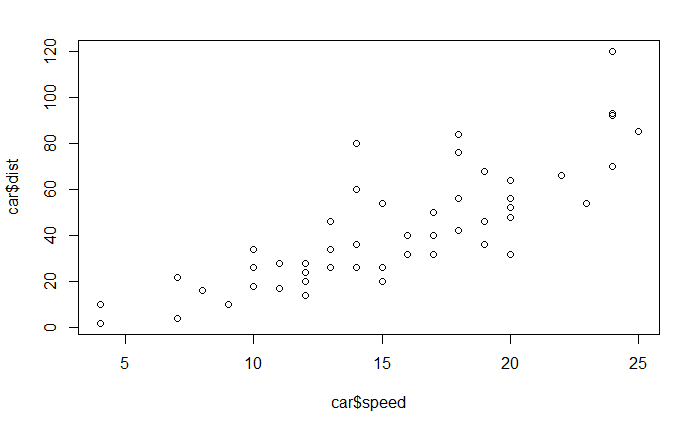

### Problem 9b

How many rows in the data frame?

Solution 9b

```r
row
```

[output not shown]

### Problem 9c

Calculate Pearsonâs correlation coefficient using the equation below:
$$r=\frac{\sum_{n}^{i=1}(x_i-\bar{x})(y_i-\bar{y})}{(n-1)s_{x}s_{y}}$$

Solution 9c

```r
speed <- car$speed
dist <- car$dist
mean.speed <- mean(speed)
mean.dist <- mean(dist)
cov <- sum((speed - mean.speed)*(dist - mean.dist))/49
sd <- sd(speed) * sd(dist)
result <- cov/sd
result
```

```
[1] 0.8068949
```

### Problem 9d

Use the cor.test() function to find Pearsonâs correlation coefficient and compare it to the one from part (c)

Solution 9d

```r
car <- cars
cor.coe <- cor.test(car$speed, car$dist, method = "pearson")[4]$estimate
number <- as.numeric(cor.coe)
if (result == number){
  print("They are same")
}else{
  print("They are not same")
}
```

```
[1] "They are not same"
```

### Problem 9e

Calculate Spearmanâs rank correlation coefficient using the equation below:
$$r_{S} = 1 - \frac{6\sum_{i=1}^{n}d_{i}^{2}}{n^3-n}$$

Solution 9e

```r
car$rankspeed <- rank(car$speed)
car$rankdist <- rank(car$dist)
dis <- car$rankspeed - car$rankdist
sum.dis <- sum(dis * dis)
rs <- 1 - (6 * sum.dis/(50^3-50))
rs
```

```
[1] 0.8308283
```

### Problem 9f

Use the cor.test() function to find Spearmanâs rank correlation coefficient and compare it to the one from part (e)

Solution 9f

```r
test <- cor.test(car$speed, car$dist, method = "spearman")
```

```
Cannot compute exact p-value with ties
```

```r
rho <- test$estimate [[1]]
rho
```

```
[1] 0.8303568
```

```r
print("They are not same")
```

```
[1] "They are not same"
```